# 2mode examples

CInguaggiato

Thursday, July 17, 2014

### Synopsis

This document deals with **two mode networks** and relates with the two-mode networks when transformed in one-mode undirected networks.

Specifically it considers cooperative innovation projects, where several subjects costitute temporary agency to make research projects.  
The participating organizations connected to each other through co-membership in innovation projects create networks.

The document argues that both the brokerage index and the intercohesive factor are related with the common participation in projects.

The approach proposed by Tore Opsahl (Opsahl and Panzarasa, 2009) is applied to get a better understanding of possible solutions.

### Empirical data

The dataset relates with the projects submitted in a call for proposal issued by Regione Piemonte in 2010. The call addresses “Life Science innovation projects”.

9 are the projects submitted.  
78 the subjects who participated.  
The list of participants per project follows:

```r
biotech<-read.table("~/GitHub/2mode/data/biotech.txt",sep=";",
                  header=T, stringsAsFactors = FALSE)
str(biotech)
```

```
## 'data.frame':    94 obs. of  2 variables:
##  $ sbj: chr  "AAA" "Aethia" "Apavadis" "Apereserce" ...
##  $ prj: chr  "PIMDMT" "PISTEM" "DRUIDI" "ATIVE" ...
```

```r
myprj<-unique(biotech$prj)

# prjsbj represents sbj for each prj

prjsbj<-sapply(myprj, function(x) biotech$sbj[biotech$prj==x])
prjsbj
```

```
## $PIMDMT
## [1] "AAA"          "Bracco"       "Cage"         "Fluody"
## [5] "FPRC"         "IM3D"         "Invento"      "UniPmn_DiSAV"
## [9] "UniTO_CMBC"
##
## $PISTEM
## [1] "Aethia"     "Eraclone"   "Erplan"     "FPRC"       "RBM"
## [6] "Sister"     "Stelar"     "UniTO_CMBC"
##
## $DRUIDI
## [1] "Apavadis"          "Chiesi"            "CreabilisTherap"
## [4] "FPRC"              "Orizon"            "RBM"
## [7] "Targetheartbiotec" "UniPmn_DiSCAFF"    "UniTO_DGBB"
##
## $ATIVE
##  [1] "Apereserce"     "CID"            "INRIM"          "lanzathomson"
##  [5] "life_device"    "PoliTO_DIMEC "  "SKE"            "SorinBiomedica"
##  [9] "UNI_PI"         "UniTO_CISRA"    "UniTO_DSCB"
##
## $IMMOMC
##  [1] "Areta"         "Bioclams"      "FPRC"          "Genovax"
##  [5] "Hmgbiotec"     "IM3D"          "Nanogen"       "Nanovector"
##  [9] "Natimab"       "Nurex"         "UniPmn_DSM"    "UniTO_DAFML"
## [13] "UniTO_DIChIFM" "UniTO_DMOS"    "UniTO_DOncUm"  "UniTO_DSCB"
##
## $PROGENNANOLAB
##  [1] "AsuMolinette"     "Biodiversity"     "Bruker"
##  [4] "Eltec"            "Inpeco"           "INRIM"
##  [7] "Micro_la"         "Olivetti_ijet"    "PoliTO_DIFIS "
## [10] "Politronica"      "RibesInformatica" "RibesRicerche"
## [13] "UniPmn"
##
## $REGENBIOTECH
##  [1] "AsuMolinette" "Crisel"       "Cyanine"      "ETG"
##  [5] "Fairglass"    "INRIM"        "MetecT"       "Micro_la"
##  [9] "NTT"          "POLITO"       "Sianegen"     "Sinergye"
## [13] "Techfab"      "tecnolab"     "TecnoparkVCO" "UniPmn"
## [17] "UNITO"        "UniTO_NIT"
##
## $IDEAS
## [1] "Bioci"     "Diasorin"  "L_Biomat"  "Notopharm" "Techfab"   "UniPmn"
##
## $TESMAS
## [1] "fbsrl"     "UNI_PI"    "Uni_RM_TV" "UNITO"
```

12 subjects participate in more than one project

```r
sbj2<-table(biotech$sbj)[table(biotech$sbj)>1]
names(sbj2)
```

```
##  [1] "AsuMolinette" "FPRC"         "IM3D"         "INRIM"
##  [5] "Micro_la"     "RBM"          "Techfab"      "UNI_PI"
##  [9] "UniPmn"       "UNITO"        "UniTO_CMBC"   "UniTO_DSCB"
```

A basic plot shows projects (in red), participants (in gold). The 12 subjects in more than one project are brown.

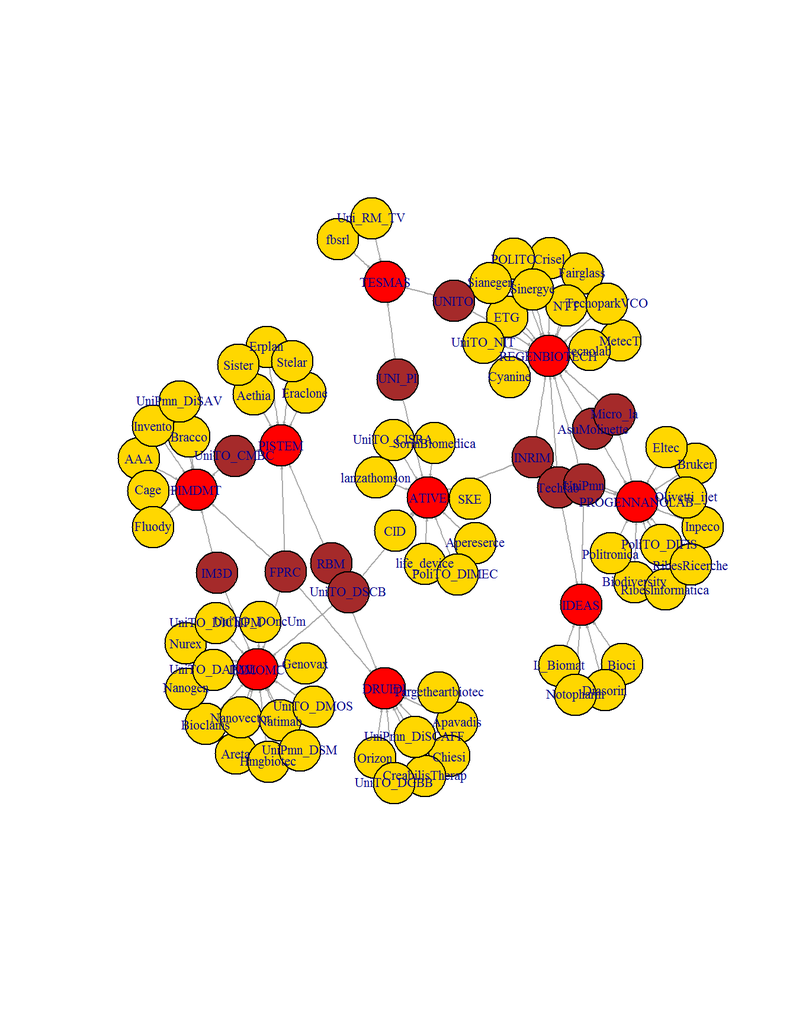

```r
library (igraph)

gbiotech <- graph.data.frame(biotech)

# set prj type <- TRUE
V(gbiotech)$type <- V(gbiotech)$name %in% biotech[,1]

v_col<-rep("gold",87)

v_col[!V(gbiotech)$type]<-c("red")
v_col[V(gbiotech)$name %in% names(sbj2)]<-c("brown")


plot.igraph(gbiotech, layout=layout.fruchterman.reingold, edge.arrow.size=0.1,
            vertex.label.cex=.7,vertex.color=v_col)
```

Then from a 2 mode network has been created the network of subjects and the network of projects.

A basic plot shows the participants divided by project. The 12 subjects in more than one project are brown.

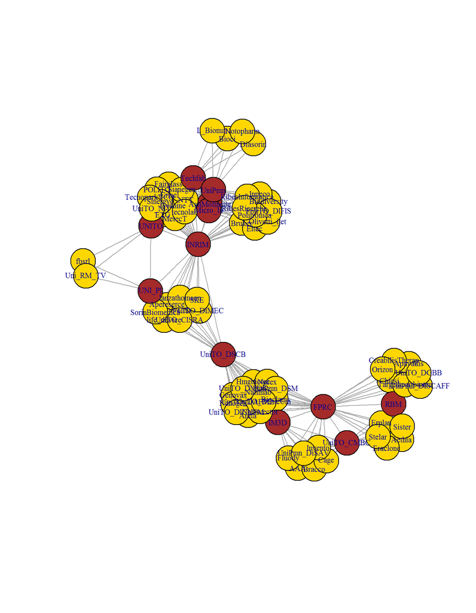

```r
nnbio<-bipartite.projection(gbiotech)


snbio<-nnbio$proj2
pnbio<-nnbio$proj1

v_col<-rep("gold",78)

v_col[V(snbio)$name %in% names(sbj2)]<-c("brown")

co<-layout.fruchterman.reingold(snbio)
plot.igraph(snbio, layout=co, edge.arrow.size=0.1,
            vertex.label.cex=.7,vertex.color=v_col,)
```

Using the *Igraph Rpackage*, local transitivity of each vertex is computed. Transitivity measures the probability that the adjacent vertices of a vertex are connected. This is sometimes also called the clustering coefficient. The local transitivity of a vertex is the ratio of the triangles connected to the vertex and the triples centered on the vertex. Algorithm uses the definition by A. Barrat.

A subject is considered as a broker when its transitivity is <1 and a nonbroker =1.

```r
# clustering coefficient
tt<-transitivity (snbio,type=c("local" ))


V(snbio)$name[tt<1]
```

```
##  [1] "AsuMolinette" "FPRC"         "IM3D"         "INRIM"
##  [5] "Micro_la"     "RBM"          "Techfab"      "UNI_PI"
##  [9] "UniPmn"       "UNITO"        "UniTO_CMBC"   "UniTO_DSCB"
```

The 12 subjects with transitivity <1 are the **same 12 subjects** in more than one project.

It is possible to check how projects overlap in term of subjects involved. The following list reports for each couple of projects the subjects which are in both projects. I.e. the projects PROGENNANOLAB ed REGENBIOTECH share 4 subjects.

```r
f<-list ()

for (i in names (prjsbj) ) {

  for (j in names (prjsbj) ) {

    if ( i != j) {

        if (mean(prjsbj[[j]]  %in% prjsbj[[i]]) >0) {

            f[[i]][[j]]<- prjsbj[[i]]  %in% prjsbj[[j]]
        }
    }

  }

}
ff<-list ()

for (i in names (prjsbj)) {

    ff[[i]]<-sapply( f[[i]], function(x) sum(x) )
}

ff
```

```
## $PIMDMT
## PISTEM DRUIDI IMMOMC
##      2      1      2
##
## $PISTEM
## PIMDMT DRUIDI IMMOMC
##      2      2      1
##
## $DRUIDI
## PIMDMT PISTEM IMMOMC
##      1      2      1
##
## $ATIVE
##        IMMOMC PROGENNANOLAB  REGENBIOTECH        TESMAS
##             1             1             1             1
##
## $IMMOMC
## PIMDMT PISTEM DRUIDI  ATIVE
##      2      1      1      1
##
## $PROGENNANOLAB
##        ATIVE REGENBIOTECH        IDEAS
##            1            4            1
##
## $REGENBIOTECH
##         ATIVE PROGENNANOLAB         IDEAS        TESMAS
##             1             4             2             1
##
## $IDEAS
## PROGENNANOLAB  REGENBIOTECH
##             1             2
##
## $TESMAS
##        ATIVE REGENBIOTECH
##            1            1
```

Now the max cliques of the network are computed. The max_clique are 10, one clique more then projects.

```r
# maximal clique
myclique<-maximal.cliques(snbio)
myclique_list<-sapply(myclique, function(x) V(snbio)$name[x])
length(myclique_list)
```

```
## [1] 10
```

The plot of the network give a specific colour to each clique and identify subjects which are common to different cliques.

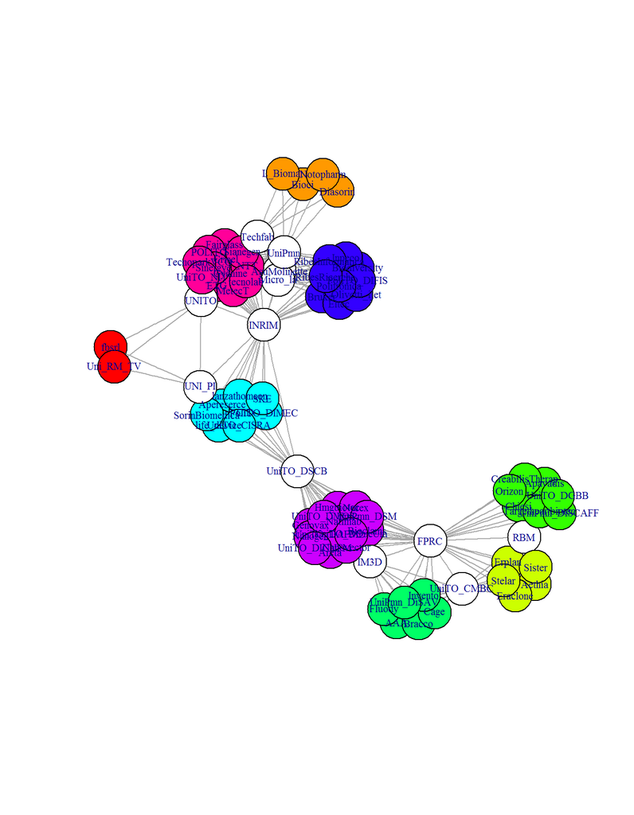

```r
##########PLOT ####################
myblocks=length(myclique)
mycolors<-rainbow(myblocks)
v_col<-rep("white",78)


j<-0
for (i in 1:myblocks){
  j<-j+1
  v_col[myclique[[i]] ]<- mycolors[j]
}
v_col[V(snbio)$name %in% names(sbj2)]<-c("white")

plot.igraph(snbio, layout=co, edge.arrow.size=0.1,
            vertex.label.cex=.7,vertex.color=v_col,)
```

It’s important to check what’s the difference between projects and clique.

```r
c<-matrix(0,10,2)
for (i in names(prjsbj)){


  for (j in 1:length(myclique_list)) {

    if (mean(myclique_list[[j]]%in%prjsbj[[i]])==1){
     c[j,1]<-j
     c[j,2]<-i
    }

  }

}
 c
```

```
##       [,1] [,2]
##  [1,] "1"  "TESMAS"
##  [2,] "2"  "IDEAS"
##  [3,] "3"  "PISTEM"
##  [4,] "4"  "DRUIDI"
##  [5,] "5"  "PIMDMT"
##  [6,] "6"  "ATIVE"
##  [7,] "0"  "0"
##  [8,] "8"  "PROGENNANOLAB"
##  [9,] "9"  "IMMOMC"
## [10,] "10" "REGENBIOTECH"
```

```r
myclique_list[[7]]
```

```
## [1] "UNI_PI" "INRIM"  "UNITO"
```

The 7th clique is made of three subjects already in the 12 common subjects.

As curiosity I tried to run the clique percolation algorithm developed by Palla et al. (2004) as it’s implemented in R language and riported in [Community Detection In R](http://igraph.wikidot.com/community-detection-in-r) with **k=3**. 3 is equal to the number of subjects in the smallest project minus 1.

```r
# clique.community FUNCTION ##############

clique.community <- function(graph, k) {
  clq <- cliques(graph, min=k, max=k)
  edges <- c()
  for (i in seq_along(clq)) {
    for (j in seq_along(clq)) {
      if ( length(unique(c(clq[[i]], clq[[j]]))) == k+1 ) {
        edges <- c(edges, c(i,j))
      }
    }
  }
  clq.graph <- simplify(graph(edges))
  V(clq.graph)$name <- seq_len(vcount(clq.graph))
  comps <- decompose.graph(clq.graph)

  lapply(comps, function(x) {
    unique(unlist(clq[ V(x)$name ]))
  })
}

cli_com3<-clique.community (snbio,3)


sapply(cli_com3, function (x) V(snbio)$name[x])
```

```
## [[1]]
##  [1] "AAA"               "Bracco"            "Cage"
##  [4] "Fluody"            "FPRC"              "IM3D"
##  [7] "Invento"           "UniPmn_DiSAV"      "UniTO_CMBC"
## [10] "Aethia"            "Eraclone"          "Erplan"
## [13] "RBM"               "Sister"            "Stelar"
## [16] "Apavadis"          "Chiesi"            "CreabilisTherap"
## [19] "Orizon"            "Targetheartbiotec" "UniPmn_DiSCAFF"
## [22] "UniTO_DGBB"        "Areta"             "Bioclams"
## [25] "Genovax"           "Hmgbiotec"         "Nanogen"
## [28] "Nanovector"        "Natimab"           "Nurex"
## [31] "UniPmn_DSM"        "UniTO_DAFML"       "UniTO_DIChIFM"
## [34] "UniTO_DMOS"        "UniTO_DOncUm"      "UniTO_DSCB"
##
## [[2]]
##  [1] "Apereserce"       "CID"              "INRIM"
##  [4] "lanzathomson"     "life_device"      "PoliTO_DIMEC "
##  [7] "SKE"              "SorinBiomedica"   "UNI_PI"
## [10] "UniTO_CISRA"      "UniTO_DSCB"       "AsuMolinette"
## [13] "Biodiversity"     "Bruker"           "Eltec"
## [16] "Inpeco"           "Micro_la"         "Olivetti_ijet"
## [19] "PoliTO_DIFIS "    "Politronica"      "RibesInformatica"
## [22] "RibesRicerche"    "UniPmn"           "Crisel"
## [25] "Cyanine"          "ETG"              "Fairglass"
## [28] "MetecT"           "NTT"              "POLITO"
## [31] "Sianegen"         "Sinergye"         "Techfab"
## [34] "tecnolab"         "TecnoparkVCO"     "UNITO"
## [37] "UniTO_NIT"        "Bioci"            "Diasorin"
## [40] "L_Biomat"         "Notopharm"        "fbsrl"
## [43] "Uni_RM_TV"
```

In this case two communities are the results of the computation. It comprises ALL subjects.

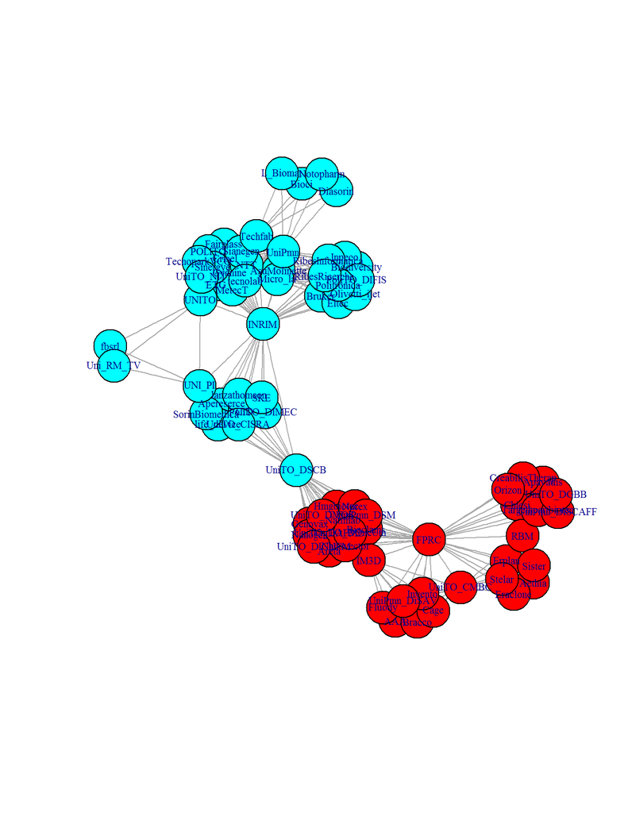

```r
blockcpm=length(cli_com3)
mycolors<-rainbow(blockcpm)
v_col<-rep("white",78)


j<-0
for (i in 1:blockcpm){
    j<-j+1
    v_col[cli_com3[[i]] ]<- mycolors[j]
}
#v_col[V(snbio)$name %in% names(sbj2)]<-c("white")

plot.igraph(snbio, layout=co, edge.arrow.size=0.1,
            vertex.label.cex=.7,vertex.color=v_col)
```

Finally I run the clustering coefficient proposed in [Clustering in Two-mode Networks](http://toreopsahl.com/tnet/two-mode-networks/clustering) by Tore Opsahl (Opsahl and Panzarasa, 2009) to check if same results holds also for this approach.

A Rpackage is available in order to compute several clustering coefficients directly on 2mode network.

```r
library (tnet)
```

```
## tnet: Analysis of Weighted, Two-mode, and Longitudinal networks.
## Type ?tnet for help.
```

```r
biotechx <- as.tnet(biotech, type="binary two-mode tnet")
str(biotechx)

pippo<-biotechx$i
biotechx$i<-as.integer(biotechx$i)
biotechx$p<-as.integer(biotechx$p)+100
#str(biotechx)


# Calculate the reinforcement coefficient (Robins and Alexander, 2004)
reinforcement_tm(biotechx)

# Calculate the global coefficient (Opsahl, 2012)
clustering_tm(biotech)

# Calculate the local coefficient (Opsahl, 2012)
clu_loc<-clustering_local_tm(biotechx)
clu_loc

clu_loc[order(clu_loc$lc),  ]

zz<-clu_loc$node[!is.na(clu_loc$lc)]
```

Taking the results local coefficient (Opsahl, 2012) I print out subjects with a output different from *NaN*.

The 12 subjects with significant coefficient are the **same 12 subjects** in more than one project.

```r
levels(pippo)[zz]
```

```
##  [1] "AsuMolinette" "FPRC"         "IM3D"         "INRIM"
##  [5] "Micro_la"     "RBM"          "Techfab"      "UNI_PI"
##  [9] "UniPmn"       "UNITO"        "UniTO_CMBC"   "UniTO_DSCB"
```